# lesson17_SPSS_Output_2018

[output not shown]

Log  
Log - Log - November 5, 2018

GET  
FILE='C:\MyGithub\N736Fall2017_lesson1415\helpmkh.sav'.  
DATASET NAME DataSet1 WINDOW=FRONT.  
* Encoding: UTF-8.  
* ========================================.  
* SPSS SYNTAX  
* Lesson 17 on Covariates and Interactions  
* i.e. moderators  
* ========================================.  
* Let's look at correlations between some  
* conceptual covariates like age, gender,  
* and perceived social support among friends  
* and associations with potential outcomes of  
* interest: pcs, mcs, cesd and indtot  
* overall correlations.  
CORRELATIONS  
/VARIABLES=age female pss_fr pcs mcs cesd indtot  
/PRINT=TWOTAIL NOSIG  
/MISSING=PAIRWISE.

Correlations  
Correlations - Active Dataset - November 5, 2018

[DataSet1] C:\MyGithub\N736Fall2017_lesson1415\helpmkh.sav

Correlations  
Correlations - Correlations - November 5, 2018

CorrelationsCorrelations, table, 1 levels of column headers and 2 levels of row headers, table with 9 columns and 25 rows

|  |  | age Age at baseline (in years) | female Gender of respondent | pss_fr Perceived Social Support - friends | pcs SF36 Physical Composite Score - Baseline | mcs SF36 Mental Composite Score - Baseline | cesd CESD total score - Baseline | indtot Inventory of Drug Use Consequences (InDue) total score - Baseline |
| --- | --- | --- | --- | --- | --- | --- | --- | --- |
| age Age at baseline (in years) | Pearson Correlation | 1 | .043 | .080 | -.229** | .045 | .008 | .026 |
|  | Sig. (2-tailed) |  | .358 | .088 | .000 | .343 | .859 | .575 |
|  | N | 453 | 453 | 453 | 453 | 453 | 453 | 453 |
| female Gender of respondent | Pearson Correlation | .043 | 1 | .067 | -.157** | -.119* | .180** | -.261** |
|  | Sig. (2-tailed) | .358 |  | .155 | .001 | .011 | .000 | .000 |
|  | N | 453 | 453 | 453 | 453 | 453 | 453 | 453 |
| pss_fr Perceived Social Support - friends | Pearson Correlation | .080 | .067 | 1 | .077 | .138** | -.184** | -.198** |
|  | Sig. (2-tailed) | .088 | .155 |  | .104 | .003 | .000 | .000 |
|  | N | 453 | 453 | 453 | 453 | 453 | 453 | 453 |
| pcs SF36 Physical Composite Score - Baseline | Pearson Correlation | -.229** | -.157** | .077 | 1 | .110* | -.293** | -.135** |
|  | Sig. (2-tailed) | .000 | .001 | .104 |  | .019 | .000 | .004 |
|  | N | 453 | 453 | 453 | 453 | 453 | 453 | 453 |
| mcs SF36 Mental Composite Score - Baseline | Pearson Correlation | .045 | -.119* | .138** | .110* | 1 | -.682** | -.381** |
|  | Sig. (2-tailed) | .343 | .011 | .003 | .019 |  | .000 | .000 |
|  | N | 453 | 453 | 453 | 453 | 453 | 453 | 453 |
| cesd CESD total score - Baseline | Pearson Correlation | .008 | .180** | -.184** | -.293** | -.682** | 1 | .336** |
|  | Sig. (2-tailed) | .859 | .000 | .000 | .000 | .000 |  | .000 |
|  | N | 453 | 453 | 453 | 453 | 453 | 453 | 453 |
| indtot Inventory of Drug Use Consequences (InDue) total score - Baseline | Pearson Correlation | .026 | -.261** | -.198** | -.135** | -.381** | .336** | 1 |
|  | Sig. (2-tailed) | .575 | .000 | .000 | .004 | .000 | .000 |  |
|  | N | 453 | 453 | 453 | 453 | 453 | 453 | 453 |

**. Correlation is significant at the 0.01 level (2-tailed).  
*. Correlation is significant at the 0.05 level (2-tailed).

Log  
Log - Log - November 5, 2018

* suppose we also consider gender as a potential  
* "moderator" of these correlations  
* SPLIT the dataset by gender and rerun the  
* correlations - look for differences in the  
* correlations by gender.  
SORT CASES BY female.  
SPLIT FILE LAYERED BY female.  
CORRELATIONS  
/VARIABLES=age female pss_fr pcs mcs cesd indtot  
/PRINT=TWOTAIL NOSIG  
/MISSING=PAIRWISE.

Correlations  
Correlations - Correlations - November 5, 2018

CorrelationsCorrelations, table, 1 levels of column headers and 3 levels of row headers, table with 10 columns and 47 rows

|  | female Gender of respondent |  | age Age at baseline (in years) | female Gender of respondent | pss_fr Perceived Social Support - friends | pcs SF36 Physical Composite Score - Baseline | mcs SF36 Mental Composite Score - Baseline | cesd CESD total score - Baseline | indtot Inventory of Drug Use Consequences (InDue) total score - Baseline |
| --- | --- | --- | --- | --- | --- | --- | --- | --- | --- |
| age Age at baseline (in years) | 0 Male | Pearson Correlation | 1 | .<sup>a</sup> | .109* | -.231** | .055 | -.002 | .094 |
|  |  | Sig. (2-tailed) |  | . | .043 | .000 | .309 | .966 | .081 |
|  |  | N | 346 | 346 | 346 | 346 | 346 | 346 | 346 |
|  | 1 Female | Pearson Correlation | 1 | .<sup>a</sup> | -.016 | -.202* | .034 | .010 | -.103 |
|  |  | Sig. (2-tailed) |  | . | .866 | .037 | .727 | .921 | .293 |
|  |  | N | 107 | 107 | 107 | 107 | 107 | 107 | 107 |
| female Gender of respondent | 0 Male | Pearson Correlation | .<sup>a</sup> | .<sup>a</sup> | .<sup>a</sup> | .<sup>a</sup> | .<sup>a</sup> | .<sup>a</sup> | .<sup>a</sup> |
|  |  | Sig. (2-tailed) | . |  | . | . | . | . | . |
|  |  | N | 346 | 346 | 346 | 346 | 346 | 346 | 346 |
|  | 1 Female | Pearson Correlation | .<sup>a</sup> | .<sup>a</sup> | .<sup>a</sup> | .<sup>a</sup> | .<sup>a</sup> | .<sup>a</sup> | .<sup>a</sup> |
|  |  | Sig. (2-tailed) | . |  | . | . | . | . | . |
|  |  | N | 107 | 107 | 107 | 107 | 107 | 107 | 107 |
| pss_fr Perceived Social Support - friends | 0 Male | Pearson Correlation | .109* | .<sup>a</sup> | 1 | .058 | .144** | -.199** | -.150** |
|  |  | Sig. (2-tailed) | .043 | . |  | .284 | .007 | .000 | .005 |
|  |  | N | 346 | 346 | 346 | 346 | 346 | 346 | 346 |
|  | 1 Female | Pearson Correlation | -.016 | .<sup>a</sup> | 1 | .185 | .159 | -.200* | -.275** |
|  |  | Sig. (2-tailed) | .866 | . |  | .056 | .103 | .039 | .004 |
|  |  | N | 107 | 107 | 107 | 107 | 107 | 107 | 107 |
| pcs SF36 Physical Composite Score - Baseline | 0 Male | Pearson Correlation | -.231** | .<sup>a</sup> | .058 | 1 | .046 | -.243** | -.113* |
|  |  | Sig. (2-tailed) | .000 | . | .284 |  | .394 | .000 | .036 |
|  |  | N | 346 | 346 | 346 | 346 | 346 | 346 | 346 |
|  | 1 Female | Pearson Correlation | -.202* | .<sup>a</sup> | .185 | 1 | .266** | -.369** | -.387** |
|  |  | Sig. (2-tailed) | .037 | . | .056 |  | .006 | .000 | .000 |
|  |  | N | 107 | 107 | 107 | 107 | 107 | 107 | 107 |
| mcs SF36 Mental Composite Score - Baseline | 0 Male | Pearson Correlation | .055 | .<sup>a</sup> | .144** | .046 | 1 | -.678** | -.411** |
|  |  | Sig. (2-tailed) | .309 | . | .007 | .394 |  | .000 | .000 |
|  |  | N | 346 | 346 | 346 | 346 | 346 | 346 | 346 |
|  | 1 Female | Pearson Correlation | .034 | .<sup>a</sup> | .159 | .266** | 1 | -.674** | -.491** |
|  |  | Sig. (2-tailed) | .727 | . | .103 | .006 |  | .000 | .000 |
|  |  | N | 107 | 107 | 107 | 107 | 107 | 107 | 107 |
| cesd CESD total score - Baseline | 0 Male | Pearson Correlation | -.002 | .<sup>a</sup> | -.199** | -.243** | -.678** | 1 | .370** |
|  |  | Sig. (2-tailed) | .966 | . | .000 | .000 | .000 |  | .000 |
|  |  | N | 346 | 346 | 346 | 346 | 346 | 346 | 346 |
|  | 1 Female | Pearson Correlation | .010 | .<sup>a</sup> | -.200* | -.369** | -.674** | 1 | .486** |
|  |  | Sig. (2-tailed) | .921 | . | .039 | .000 | .000 |  | .000 |
|  |  | N | 107 | 107 | 107 | 107 | 107 | 107 | 107 |
| indtot Inventory of Drug Use Consequences (InDue) total score - Baseline | 0 Male | Pearson Correlation | .094 | .<sup>a</sup> | -.150** | -.113* | -.411** | .370** | 1 |
|  |  | Sig. (2-tailed) | .081 | . | .005 | .036 | .000 | .000 |  |
|  |  | N | 346 | 346 | 346 | 346 | 346 | 346 | 346 |
|  | 1 Female | Pearson Correlation | -.103 | .<sup>a</sup> | -.275** | -.387** | -.491** | .486** | 1 |
|  |  | Sig. (2-tailed) | .293 | . | .004 | .000 | .000 | .000 |  |
|  |  | N | 107 | 107 | 107 | 107 | 107 | 107 | 107 |

*. Correlation is significant at the 0.05 level (2-tailed).  
**. Correlation is significant at the 0.01 level (2-tailed).  
a. Cannot be computed because at least one of the variables is constant.

Log  
Log - Log - November 5, 2018

SPLIT FILE OFF.  
* look at the differences in the correlations  
* by gender for the association between  
* mcs and pcs - mental and physical composite  
* scores from the SF36 - the association  
* is stronger for females.  
* test if there is an interaction effect between  
* pcs and gender for mcs as the outcome.  
* in SPSS for the linear regression module,  
* we need to 1st compute an interaction  
* effect between pcs and gender. Since gender is  
* already coded 0,1, we can just compute the interaction  
* without mean-centering. For continuous predictors,  
* we should 1st mean center for effects.  
compute pcs_x_female = pcs * female.  
execute.  
* run a regression model  
* put in gender - female  
* then put in pcs  
* then put in the interaction effect between them  
* look at the p-values and changes in r2 for each step.  
REGRESSION  
/DESCRIPTIVES MEAN STDDEV CORR SIG N  
/MISSING LISTWISE  
/STATISTICS COEFF OUTS CI(95) R ANOVA COLLIN TOL CHANGE ZPP  
/CRITERIA=PIN(.05) POUT(.10)  
/NOORIGIN  
/DEPENDENT mcs  
/METHOD=ENTER female  
/METHOD=ENTER pcs  
/METHOD=ENTER pcs_x_female  
/RESIDUALS HISTOGRAM(ZRESID) NORMPROB(ZRESID).

Regression  
Regression - Descriptive Statistics - November 5, 2018

Descriptive StatisticsDescriptive Statistics, table, 1 levels of column headers and 1 levels of row headers, table with 4 columns and 6 rows

|  | Mean | Std. Deviation | N |
| --- | --- | --- | --- |
| mcs SF36 Mental Composite Score - Baseline | 31.676678300000000 | 12.839337310000000 | 453 |
| female Gender of respondent | .24 | .425 | 453 |
| pcs SF36 Physical Composite Score - Baseline | 48.048541550000000 | 10.784602690000000 | 453 |
| pcs_x_female | 10.6330 | 19.75841 | 453 |

Regression  
Regression - Correlations - November 5, 2018

CorrelationsCorrelations, table, 1 levels of column headers and 2 levels of row headers, table with 6 columns and 14 rows

|  |  | mcs SF36 Mental Composite Score - Baseline | female Gender of respondent | pcs SF36 Physical Composite Score - Baseline | pcs_x_female |
| --- | --- | --- | --- | --- | --- |
| Pearson Correlation | mcs SF36 Mental Composite Score - Baseline | 1.000 | -.119 | .110 | -.084 |
|  | female Gender of respondent | -.119 | 1.000 | -.157 | .969 |
|  | pcs SF36 Physical Composite Score - Baseline | .110 | -.157 | 1.000 | -.039 |
|  | pcs_x_female | -.084 | .969 | -.039 | 1.000 |
| Sig. (1-tailed) | mcs SF36 Mental Composite Score - Baseline | . | .006 | .009 | .037 |
|  | female Gender of respondent | .006 | . | .000 | .000 |
|  | pcs SF36 Physical Composite Score - Baseline | .009 | .000 | . | .203 |
|  | pcs_x_female | .037 | .000 | .203 | . |
| N | mcs SF36 Mental Composite Score - Baseline | 453 | 453 | 453 | 453 |
|  | female Gender of respondent | 453 | 453 | 453 | 453 |
|  | pcs SF36 Physical Composite Score - Baseline | 453 | 453 | 453 | 453 |
|  | pcs_x_female | 453 | 453 | 453 | 453 |

Regression  
Regression - Variables Entered/Removed - November 5, 2018

Variables Entered/Removed<sup>a</sup>Variables Entered/Removed, table, 1 levels of column headers and 1 levels of row headers, table with 4 columns and 7 rows

| Model | Variables Entered | Variables Removed | Method |
| --- | --- | --- | --- |
| 1 | female Gender of respondent<sup>b</sup> | . | Enter |
| 2 | pcs SF36 Physical Composite Score - Baseline<sup>b</sup> | . | Enter |
| 3 | pcs_x_female<sup>b</sup> | . | Enter |

a. Dependent Variable: mcs SF36 Mental Composite Score - Baseline  
b. All requested variables entered.

Regression  
Regression - Model Summary - November 5, 2018

Model Summary<sup>d</sup>Model Summary, table, 2 levels of column headers and 1 levels of row headers, table with 10 columns and 10 rows

| Model | R | R Square | Adjusted R Square | Std. Error of the Estimate | Change Statistics |  |  |  |  |
| --- | --- | --- | --- | --- | --- | --- | --- | --- | --- |
|  |  |  |  |  | R Square Change | F Change | df1 | df2 | Sig. F Change |
| 1 | .119<sup>a</sup> | .014 | .012 | 12.762679000000000 | .014 | 6.446 | 1 | 451 | .011 |
| 2 | .151<sup>b</sup> | .023 | .018 | 12.720657510000000 | .009 | 3.985 | 1 | 450 | .047 |
| 3 | .177<sup>c</sup> | .031 | .025 | 12.679310190000000 | .009 | 3.940 | 1 | 449 | .048 |

a. Predictors: (Constant), female Gender of respondent  
b. Predictors: (Constant), female Gender of respondent, pcs SF36 Physical Composite Score - Baseline  
c. Predictors: (Constant), female Gender of respondent, pcs SF36 Physical Composite Score - Baseline, pcs_x_female  
d. Dependent Variable: mcs SF36 Mental Composite Score - Baseline

Regression  
Regression - ANOVA - November 5, 2018

ANOVA<sup>a</sup>ANOVA, table, 1 levels of column headers and 2 levels of row headers, table with 7 columns and 15 rows

| Model |  | Sum of Squares | df | Mean Square | F | Sig. |
| --- | --- | --- | --- | --- | --- | --- |
| 1 | Regression | 1049.984 | 1 | 1049.984 | 6.446 | .011<sup>b</sup> |
|  | Residual | 73461.575 | 451 | 162.886 |  |  |
|  | Total | 74511.559 | 452 |  |  |  |
| 2 | Regression | 1694.752 | 2 | 847.376 | 5.237 | .006<sup>c</sup> |
|  | Residual | 72816.807 | 450 | 161.815 |  |  |
|  | Total | 74511.559 | 452 |  |  |  |
| 3 | Regression | 2328.116 | 3 | 776.039 | 4.827 | .003<sup>d</sup> |
|  | Residual | 72183.443 | 449 | 160.765 |  |  |
|  | Total | 74511.559 | 452 |  |  |  |

a. Dependent Variable: mcs SF36 Mental Composite Score - Baseline  
b. Predictors: (Constant), female Gender of respondent  
c. Predictors: (Constant), female Gender of respondent, pcs SF36 Physical Composite Score - Baseline  
d. Predictors: (Constant), female Gender of respondent, pcs SF36 Physical Composite Score - Baseline, pcs_x_female

Regression  
Regression - Coefficients - November 5, 2018

Coefficients<sup>a</sup>Coefficients, table, 2 levels of column headers and 2 levels of row headers, table with 14 columns and 13 rows

| Model |  | Unstandardized Coefficients |  | Standardized Coefficients | t | Sig. | 95.0% Confidence Interval for B |  | Correlations |  |  | Collinearity Statistics |  |
| --- | --- | --- | --- | --- | --- | --- | --- | --- | --- | --- | --- | --- | --- |
|  |  | B | Std. Error | Beta |  |  | Lower Bound | Upper Bound | Zero-order | Partial | Part | Tolerance | VIF |
| 1 | (Constant) | 32.523 | .686 |  | 47.401 | .000 | 31.175 | 33.872 |  |  |  |  |  |
|  | female Gender of respondent | -3.584 | 1.412 | -.119 | -2.539 | .011 | -6.359 | -.810 | -.119 | -.119 | -.119 | 1.000 | 1.000 |
| 2 | (Constant) | 27.031 | 2.835 |  | 9.533 | .000 | 21.458 | 32.603 |  |  |  |  |  |
|  | female Gender of respondent | -3.139 | 1.425 | -.104 | -2.203 | .028 | -5.939 | -.339 | -.119 | -.103 | -.103 | .975 | 1.025 |
|  | pcs SF36 Physical Composite Score - Baseline | .112 | .056 | .094 | 1.996 | .047 | .002 | .223 | .110 | .094 | .093 | .975 | 1.025 |
| 3 | (Constant) | 29.849 | 3.163 |  | 9.437 | .000 | 23.633 | 36.065 |  |  |  |  |  |
|  | female Gender of respondent | -15.620 | 6.446 | -.517 | -2.423 | .016 | -28.288 | -2.951 | -.119 | -.114 | -.113 | .047 | 21.124 |
|  | pcs SF36 Physical Composite Score - Baseline | .055 | .063 | .046 | .866 | .387 | -.069 | .178 | .110 | .041 | .040 | .769 | 1.300 |
|  | pcs_x_female | .272 | .137 | .419 | 1.985 | .048 | .003 | .542 | -.084 | .093 | .092 | .048 | 20.638 |

a. Dependent Variable: mcs SF36 Mental Composite Score - Baseline

Regression  
Regression - Excluded Variables - November 5, 2018

Excluded Variables<sup>a</sup>Excluded Variables, table, 2 levels of column headers and 2 levels of row headers, table with 9 columns and 9 rows

| Model |  | Beta In | t | Sig. | Partial Correlation | Collinearity Statistics |  |  |
| --- | --- | --- | --- | --- | --- | --- | --- | --- |
|  |  |  |  |  |  | Tolerance | VIF | Minimum Tolerance |
| 1 | pcs SF36 Physical Composite Score - Baseline | .094<sup>b</sup> | 1.996 | .047 | .094 | .975 | 1.025 | .975 |
|  | pcs_x_female | .503<sup>b</sup> | 2.684 | .008 | .126 | .061 | 16.275 | .061 |
| 2 | pcs_x_female | .419<sup>c</sup> | 1.985 | .048 | .093 | .048 | 20.638 | .047 |

a. Dependent Variable: mcs SF36 Mental Composite Score - Baseline  
b. Predictors in the Model: (Constant), female Gender of respondent  
c. Predictors in the Model: (Constant), female Gender of respondent, pcs SF36 Physical Composite Score - Baseline

Regression  
Regression - Collinearity Diagnostics - November 5, 2018

Collinearity Diagnostics<sup>a</sup>Collinearity Diagnostics, table, 2 levels of column headers and 2 levels of row headers, table with 8 columns and 13 rows

| Model | Dimension | Eigenvalue | Condition Index | Variance Proportions |  |  |  |
| --- | --- | --- | --- | --- | --- | --- | --- |
|  |  |  |  | (Constant) | female Gender of respondent | pcs SF36 Physical Composite Score - Baseline | pcs_x_female |
| 1 | 1 | 1.486 | 1.000 | .26 | .26 |  |  |
|  | 2 | .514 | 1.700 | .74 | .74 |  |  |
| 2 | 1 | 2.307 | 1.000 | .01 | .07 | .01 |  |
|  | 2 | .670 | 1.856 | .01 | .89 | .01 |  |
|  | 3 | .023 | 9.999 | .99 | .05 | .98 |  |
| 3 | 1 | 2.906 | 1.000 | .00 | .00 | .00 | .00 |
|  | 2 | 1.046 | 1.667 | .01 | .01 | .01 | .01 |
|  | 3 | .035 | 9.085 | .25 | .25 | .25 | .28 |
|  | 4 | .013 | 15.240 | .74 | .74 | .74 | .70 |

a. Dependent Variable: mcs SF36 Mental Composite Score - Baseline

Regression  
Regression - Residuals Statistics - November 5, 2018

Residuals Statistics<sup>a</sup>Residuals Statistics, table, 1 levels of column headers and 1 levels of row headers, table with 6 columns and 7 rows

|  | Minimum | Maximum | Mean | Std. Deviation | N |
| --- | --- | --- | --- | --- | --- |
| Predicted Value | 21.391777040000000 | 36.831836700000004 | 31.676678300000000 | 2.269515227000000 | 453 |
| Residual | -27.169780730000000 | 32.866035460000000 | .000000000000003 | 12.637162780000000 | 453 |
| Std. Predicted Value | -4.532 | 2.271 | .000 | 1.000 | 453 |
| Std. Residual | -2.143 | 2.592 | .000 | .997 | 453 |

a. Dependent Variable: mcs SF36 Mental Composite Score - Baseline

Charts  
Charts - *zresid Histogram - November 5, 2018

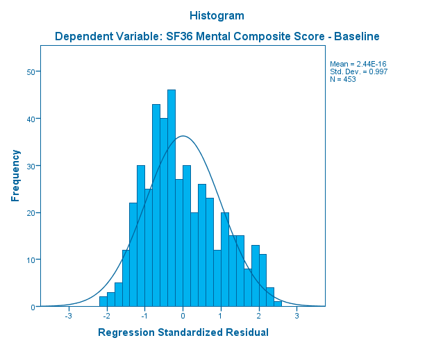

Charts  
Charts - *zresid Normal P-P Plot - November 5, 2018

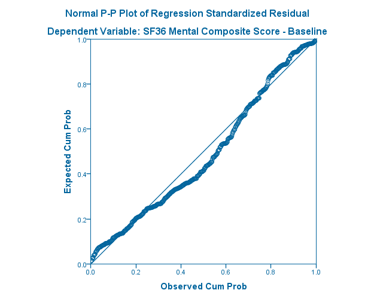

Log  
Log - Log - November 5, 2018

* notice that gender is a significant predictor  
* conceptually it is a significant "covariate"  
* you can see this from Model 1 (BLOCK 1)  
* AFTER adjusting for gender, pcs is a  
* significant predictor of mcs - see Model 2  
* However, once you add the interaction term  
* you'll notice that pcs_x_female is significant  
* and the pcs term is no longer significant  
* there is a significant interaction between  
* pcs and gender - gender is a significant moderator  
* of the effect between pcs and mcs.  
* let's try this using an ANCOVA approach  
* Analysis of Covariance Approach  
* set mcs = dependent variable  
* set female = fixed factor (because it is categorical)  
* set pcs = covariate (because it is continuous)  
* note that model defaults to full factorial  
* but his does NOT include the interaction effect  
* so select custom and build a model  
* with the 2 main effects plus the interaction effect  
* see /DESIGN= in the SYNTAX below  
* in the options be sure to check the box  
* for parameter effects to see the coefficients  
* similar to the regression output.  
UNIANOVA mcs BY female WITH pcs  
/METHOD=SSTYPE(3)  
/INTERCEPT=INCLUDE  
/PRINT=ETASQ DESCRIPTIVE PARAMETER HOMOGENEITY  
/CRITERIA=ALPHA(.05)  
/DESIGN=female pcs female*pcs.

Univariate Analysis of Variance  
Univariate Analysis of Variance - Between-Subjects Factors - November 5, 2018

Between-Subjects FactorsBetween-Subjects Factors, table, 1 levels of column headers and 2 levels of row headers, table with 4 columns and 4 rows

|  |  | Value Label | N |
| --- | --- | --- | --- |
| female Gender of respondent | 0 | Male | 346 |
|  | 1 | Female | 107 |

Univariate Analysis of Variance  
Univariate Analysis of Variance - Descriptive Statistics - November 5, 2018

Descriptive StatisticsDescriptive Statistics, table, Dependent Variable, mcs SF36 Mental Composite Score - Baseline, 1 layers, 1 levels of column headers and 1 levels of row headers, table with 4 columns and 6 rows

| mcs SF36 Mental Composite Score - Baseline mcs SF36 Mental Composite Score - Baseline |  |  |  |
| --- | --- | --- | --- |
| female Gender of respondent | Mean | Std. Deviation | N |
| 0 Male | 32.523313200000004 | 12.870236490000000 | 346 |
| 1 Female | 28.938961720000000 | 12.406154990000001 | 107 |
| Total | 31.676678300000000 | 12.839337310000000 | 453 |

Univariate Analysis of Variance  
Univariate Analysis of Variance - Levene's Test of Equality of Error Variances - November 5, 2018

Levene's Test of Equality of Error Variances<sup>a</sup>Levene's Test of Equality of Error Variances, table, Dependent Variable, mcs SF36 Mental Composite Score - Baseline, 1 layers, 1 levels of column headers and 0 levels of row headers, table with 4 columns and 6 rows

| mcs SF36 Mental Composite Score - Baseline mcs SF36 Mental Composite Score - Baseline |  |  |  |
| --- | --- | --- | --- |
| F | df1 | df2 | Sig. |
| 4.000 | 1 | 451 | .046 |

Tests the null hypothesis that the error variance of the dependent variable is equal across groups.  
a. Design: Intercept + female + pcs + female * pcs

Univariate Analysis of Variance  
Univariate Analysis of Variance - Tests of Between-Subjects Effects - November 5, 2018

Tests of Between-Subjects EffectsTests of Between-Subjects Effects, table, Dependent Variable, mcs SF36 Mental Composite Score - Baseline, 1 layers, 1 levels of column headers and 1 levels of row headers, table with 7 columns and 12 rows

| mcs SF36 Mental Composite Score - Baseline mcs SF36 Mental Composite Score - Baseline |  |  |  |  |  |  |
| --- | --- | --- | --- | --- | --- | --- |
| Source | Type III Sum of Squares | df | Mean Square | F | Sig. | Partial Eta Squared |
| Corrected Model | 2328.116<sup>a</sup> | 3 | 776.039 | 4.827 | .003 | .031 |
| Intercept | 7516.967 | 1 | 7516.967 | 46.758 | .000 | .094 |
| female | 943.910 | 1 | 943.910 | 5.871 | .016 | .013 |
| pcs | 1243.360 | 1 | 1243.360 | 7.734 | .006 | .017 |
| female * pcs | 633.364 | 1 | 633.364 | 3.940 | .048 | .009 |
| Error | 72183.443 | 449 | 160.765 |  |  |  |
| Total | 529057.172 | 453 |  |  |  |  |
| Corrected Total | 74511.559 | 452 |  |  |  |  |

a. R Squared = .031 (Adjusted R Squared = .025)

Univariate Analysis of Variance  
Univariate Analysis of Variance - Parameter Estimates - November 5, 2018

Parameter EstimatesParameter Estimates, table, Dependent Variable, mcs SF36 Mental Composite Score - Baseline, 1 layers, 2 levels of column headers and 1 levels of row headers, table with 8 columns and 11 rows

| mcs SF36 Mental Composite Score - Baseline mcs SF36 Mental Composite Score - Baseline |  |  |  |  |  |  |  |  |
| --- | --- | --- | --- | --- | --- | --- | --- | --- |
| Parameter | B | Std. Error | t | Sig. | 95% Confidence Interval |  | Partial Eta Squared |  |
|  |  |  |  |  | Lower Bound | Upper Bound |  |  |
| Intercept | 14.230 | 5.617 | 2.533 | .012 | 3.191 | 25.268 |  | .014 |
| [female=0] | 15.620 | 6.446 | 2.423 | .016 | 2.951 | 28.288 | .013 |  |
| [female=1] | 0<sup>a</sup> | . | . | . | . | . | . |  |
| pcs | .327 | .122 | 2.683 | .008 | .087 | .566 | .016 |  |
| [female=0] * pcs | -.272 | .137 | -1.985 | .048 | -.542 | -.003 | .009 |  |
| [female=1] * pcs | 0<sup>a</sup> | . | . | . | . | . | . |  |

a. This parameter is set to zero because it is redundant.

Log  
Log - Log - November 5, 2018

* compare the parameter estimates table from the ANCOVA  
* to the coefficients tables from the regression  
* what do you notice? The intercept and interaction  
* coefficients are different - why?  
* the default contrast computed in SPSS actually flips  
* the coding for males and females  
* this has to do with contrast coding in SPSS  
* so let's flip the coding for gender  
* compute males to set male=1 and female=0.  
compute male = female=0.  
execute.  
* rerun the ANCOVA model.  
UNIANOVA mcs BY male WITH pcs  
/METHOD=SSTYPE(3)  
/INTERCEPT=INCLUDE  
/PRINT=ETASQ DESCRIPTIVE PARAMETER HOMOGENEITY  
/CRITERIA=ALPHA(.05)  
/DESIGN=male pcs male*pcs.

Univariate Analysis of Variance  
Univariate Analysis of Variance - Between-Subjects Factors - November 5, 2018

Between-Subjects FactorsBetween-Subjects Factors, table, 1 levels of column headers and 2 levels of row headers, table with 3 columns and 4 rows

|  |  | N |
| --- | --- | --- |
| male | .00 | 107 |
|  | 1.00 | 346 |

Univariate Analysis of Variance  
Univariate Analysis of Variance - Descriptive Statistics - November 5, 2018

Descriptive StatisticsDescriptive Statistics, table, Dependent Variable, mcs SF36 Mental Composite Score - Baseline, 1 layers, 1 levels of column headers and 1 levels of row headers, table with 4 columns and 6 rows

| mcs SF36 Mental Composite Score - Baseline mcs SF36 Mental Composite Score - Baseline |  |  |  |
| --- | --- | --- | --- |
| male | Mean | Std. Deviation | N |
| .00 | 28.938961720000000 | 12.406154990000001 | 107 |
| 1.00 | 32.523313200000004 | 12.870236490000000 | 346 |
| Total | 31.676678300000000 | 12.839337310000000 | 453 |

Univariate Analysis of Variance  
Univariate Analysis of Variance - Levene's Test of Equality of Error Variances - November 5, 2018

Levene's Test of Equality of Error Variances<sup>a</sup>Levene's Test of Equality of Error Variances, table, Dependent Variable, mcs SF36 Mental Composite Score - Baseline, 1 layers, 1 levels of column headers and 0 levels of row headers, table with 4 columns and 6 rows

| mcs SF36 Mental Composite Score - Baseline mcs SF36 Mental Composite Score - Baseline |  |  |  |
| --- | --- | --- | --- |
| F | df1 | df2 | Sig. |
| 4.000 | 1 | 451 | .046 |

Tests the null hypothesis that the error variance of the dependent variable is equal across groups.  
a. Design: Intercept + male + pcs + male * pcs

Univariate Analysis of Variance  
Univariate Analysis of Variance - Tests of Between-Subjects Effects - November 5, 2018

Tests of Between-Subjects EffectsTests of Between-Subjects Effects, table, Dependent Variable, mcs SF36 Mental Composite Score - Baseline, 1 layers, 1 levels of column headers and 1 levels of row headers, table with 7 columns and 12 rows

| mcs SF36 Mental Composite Score - Baseline mcs SF36 Mental Composite Score - Baseline |  |  |  |  |  |  |
| --- | --- | --- | --- | --- | --- | --- |
| Source | Type III Sum of Squares | df | Mean Square | F | Sig. | Partial Eta Squared |
| Corrected Model | 2328.116<sup>a</sup> | 3 | 776.039 | 4.827 | .003 | .031 |
| Intercept | 7516.967 | 1 | 7516.967 | 46.758 | .000 | .094 |
| male | 943.910 | 1 | 943.910 | 5.871 | .016 | .013 |
| pcs | 1243.360 | 1 | 1243.360 | 7.734 | .006 | .017 |
| male * pcs | 633.364 | 1 | 633.364 | 3.940 | .048 | .009 |
| Error | 72183.443 | 449 | 160.765 |  |  |  |
| Total | 529057.172 | 453 |  |  |  |  |
| Corrected Total | 74511.559 | 452 |  |  |  |  |

a. R Squared = .031 (Adjusted R Squared = .025)

Univariate Analysis of Variance  
Univariate Analysis of Variance - Parameter Estimates - November 5, 2018

Parameter EstimatesParameter Estimates, table, Dependent Variable, mcs SF36 Mental Composite Score - Baseline, 1 layers, 2 levels of column headers and 1 levels of row headers, table with 8 columns and 11 rows

| mcs SF36 Mental Composite Score - Baseline mcs SF36 Mental Composite Score - Baseline |  |  |  |  |  |  |  |  |
| --- | --- | --- | --- | --- | --- | --- | --- | --- |
| Parameter | B | Std. Error | t | Sig. | 95% Confidence Interval |  | Partial Eta Squared |  |
|  |  |  |  |  | Lower Bound | Upper Bound |  |  |
| Intercept | 29.849 | 3.163 | 9.437 | .000 | 23.633 | 36.065 |  | .166 |
| [male=.00] | -15.620 | 6.446 | -2.423 | .016 | -28.288 | -2.951 | .013 |  |
| [male=1.00] | 0<sup>a</sup> | . | . | . | . | . | . |  |
| pcs | .055 | .063 | .866 | .387 | -.069 | .178 | .002 |  |
| [male=.00] * pcs | .272 | .137 | 1.985 | .048 | .003 | .542 | .009 |  |
| [male=1.00] * pcs | 0<sup>a</sup> | . | . | . | . | . | . |  |

a. This parameter is set to zero because it is redundant.

Log  
Log - Log - November 5, 2018

* let's make a plot of mcs by pcs by gender.  
GRAPH  
/SCATTERPLOT(BIVAR)=pcs WITH mcs BY female  
/MISSING=LISTWISE.

Graph  
Graph - Scatter of mcs pcs by female - November 5, 2018

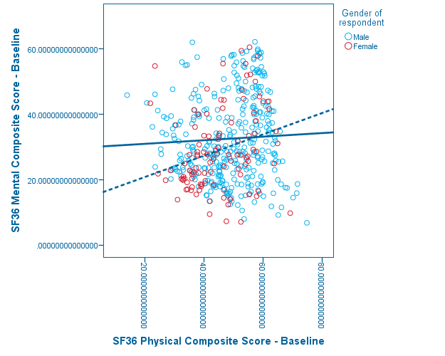


Log  
Log - Log - November 5, 2018

* and let's overlay the fitted lines for each gender  
* we can compute these by hand.  
* regression line  
* mcs = 29.849 - 15.620(female) + 0.055(pcs) + 0.272(pcs*female)  
* when female=0 for MALES  
* mcs = 29.849 + 0.055(pcs)  
* when female=1 for FEMALES  
* mcs = [29.849 - 15.620] + [0.055 + 0.272](pcs)  
* mcs = 14.229 + 0.327(pcs).

[output not shown]

[output not shown]

[output not shown]

[output not shown]

[output not shown]

[output not shown]

[output not shown]

[output not shown]

[output not shown]